White wine quality dataset exploration by Paula Jasper

========================================================

This report explores a dataset containing attributes for 4898 white wines from the Portuguese ‘Vinho Verde’ range. There are input variables containing the chemical properties of the wines, and an output variable which is the quality rating (0 is lowest quality to 10 which is the highest quality).

# Univariate Plots Section

First I will look at the dimensions, variable, dataset structure and print a summary of the dataset.

```
## [1] 4898   13
```

```
##  [1] "X"                    "fixed.acidity"        "volatile.acidity"
##  [4] "citric.acid"          "residual.sugar"       "chlorides"
##  [7] "free.sulfur.dioxide"  "total.sulfur.dioxide" "density"
## [10] "pH"                   "sulphates"            "alcohol"
## [13] "quality"
```

# Variables and descriptions

Input variables (based on physicochemical tests):  
1 - fixed acidity (tartaric acid - g / dm^3)  
2 - volatile acidity (acetic acid - g / dm^3: the amount of acetic acid in wine, which at too high a level can lead to an unpleasant, vinegar taste).  
3 - citric acid (g / dm^3: Can add ‘freshness’ and flavor to wines).  
4 - residual sugar (g / dm^3: amount of sugar remaining after fermentation stops, rare to find wines with less than 1 gram/liter and wines with greater than 45 grams/liter are considered sweet.)  
5 - chlorides (sodium chloride - g / dm^3: amount of salt in the wine).  
6 - free sulfur dioxide (mg / dm^3)  
7 - total sulfur dioxide (mg / dm^3: amount of free and bound forms of S02;  
in low concentrations, SO2 is mostly undetectable in wine, but at free SO2 concentrations over 50 ppm, SO2 becomes evident in the nose and taste of wine).  
8 - density (g / cm^3: relates to the percent alcohol and sugar content).  
9 - pH (how acidic or basic a wine is on a scale from 0 (very acidic) to 14 (very basic); most wines are between 3-4 scale).  
10 - sulphates (potassium sulphate - g/dm3: wine additive which can contribute to sulfur dioxide gas (S02) levels wich acts as an antimicrobial and antioxidant.)  
11 - alcohol (% by volume)  
Output variable (based on sensory data):  
12 - quality (score between 0 and 10)

```
## 'data.frame':    4898 obs. of  13 variables:
##  $ X                   : int  1 2 3 4 5 6 7 8 9 10 ...
##  $ fixed.acidity       : num  7 6.3 8.1 7.2 7.2 8.1 6.2 7 6.3 8.1 ...
##  $ volatile.acidity    : num  0.27 0.3 0.28 0.23 0.23 0.28 0.32 0.27 0.3 0.22 ...
##  $ citric.acid         : num  0.36 0.34 0.4 0.32 0.32 0.4 0.16 0.36 0.34 0.43 ...
##  $ residual.sugar      : num  20.7 1.6 6.9 8.5 8.5 6.9 7 20.7 1.6 1.5 ...
##  $ chlorides           : num  0.045 0.049 0.05 0.058 0.058 0.05 0.045 0.045 0.049 0.044 ...
##  $ free.sulfur.dioxide : num  45 14 30 47 47 30 30 45 14 28 ...
##  $ total.sulfur.dioxide: num  170 132 97 186 186 97 136 170 132 129 ...
##  $ density             : num  1.001 0.994 0.995 0.996 0.996 ...
##  $ pH                  : num  3 3.3 3.26 3.19 3.19 3.26 3.18 3 3.3 3.22 ...
##  $ sulphates           : num  0.45 0.49 0.44 0.4 0.4 0.44 0.47 0.45 0.49 0.45 ...
##  $ alcohol             : num  8.8 9.5 10.1 9.9 9.9 10.1 9.6 8.8 9.5 11 ...
##  $ quality             : int  6 6 6 6 6 6 6 6 6 6 ...
```

All the input variables are continuous and numeric.  
The response variable - Quality - is also a numeric variable.  
I will create a new variable, a factor quality.categ from this later.  
Below are summary descriptive statistics for the dataset.

```
##  fixed.acidity    volatile.acidity  citric.acid     residual.sugar
##  Min.   : 3.800   Min.   :0.0800   Min.   :0.0000   Min.   : 0.600
##  1st Qu.: 6.300   1st Qu.:0.2100   1st Qu.:0.2700   1st Qu.: 1.700
##  Median : 6.800   Median :0.2600   Median :0.3200   Median : 5.200
##  Mean   : 6.855   Mean   :0.2782   Mean   :0.3342   Mean   : 6.391
##  3rd Qu.: 7.300   3rd Qu.:0.3200   3rd Qu.:0.3900   3rd Qu.: 9.900
##  Max.   :14.200   Max.   :1.1000   Max.   :1.6600   Max.   :65.800
##    chlorides       free.sulfur.dioxide total.sulfur.dioxide
##  Min.   :0.00900   Min.   :  2.00      Min.   :  9.0
##  1st Qu.:0.03600   1st Qu.: 23.00      1st Qu.:108.0
##  Median :0.04300   Median : 34.00      Median :134.0
##  Mean   :0.04577   Mean   : 35.31      Mean   :138.4
##  3rd Qu.:0.05000   3rd Qu.: 46.00      3rd Qu.:167.0
##  Max.   :0.34600   Max.   :289.00      Max.   :440.0
##     density             pH          sulphates         alcohol
##  Min.   :0.9871   Min.   :2.720   Min.   :0.2200   Min.   : 8.00
##  1st Qu.:0.9917   1st Qu.:3.090   1st Qu.:0.4100   1st Qu.: 9.50
##  Median :0.9937   Median :3.180   Median :0.4700   Median :10.40
##  Mean   :0.9940   Mean   :3.188   Mean   :0.4898   Mean   :10.51
##  3rd Qu.:0.9961   3rd Qu.:3.280   3rd Qu.:0.5500   3rd Qu.:11.40
##  Max.   :1.0390   Max.   :3.820   Max.   :1.0800   Max.   :14.20
##     quality
##  Min.   :3.000
##  1st Qu.:5.000
##  Median :6.000
##  Mean   :5.878
##  3rd Qu.:6.000
##  Max.   :9.000
```

In this section I am going to plot histograms for many of the variables.

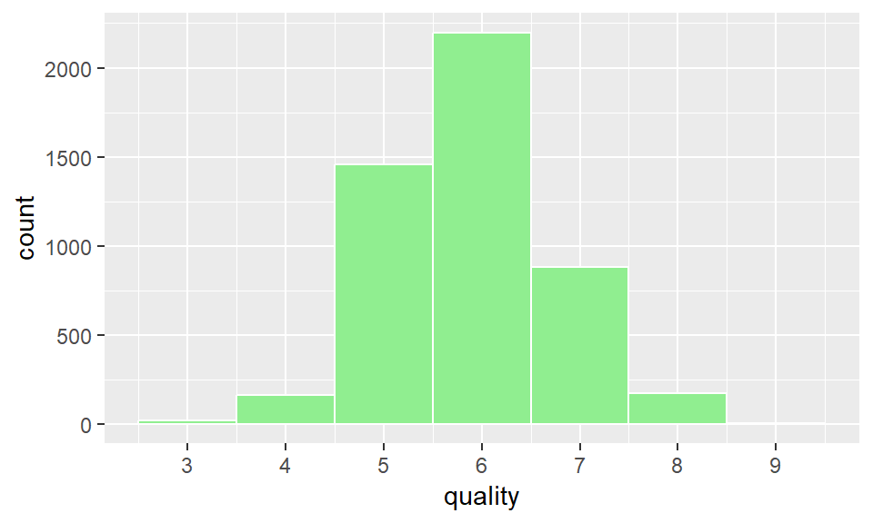

```
##    Min. 1st Qu.  Median    Mean 3rd Qu.    Max.
##   3.000   5.000   6.000   5.878   6.000   9.000
```

```
##
##    3    4    5    6    7    8    9
##   20  163 1457 2198  880  175    5
```

Quality is the response variable for this dataset. It is an evaluation ranging from 0 (worst) to 10 (best). However, these samples range from 3 to 9. The plot shows that a quality rating of 6 is the most common (2198 obs).

New categorical variable quality.categs to be used for further analysis. Low (below mode of 6), Average (mode), High (greater than the mode)

```
##  Factor w/ 3 levels "Low","Average",..: 2 2 2 2 2 2 2 2 2 2 ...
```

```
##
##     Low Average    High
##    1640    2198    1060
```

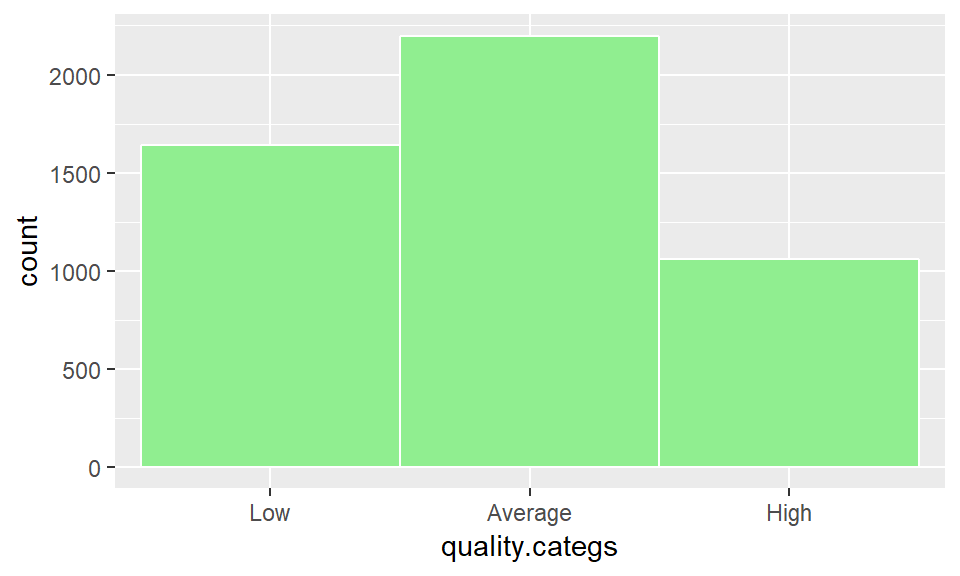

Plot shows most wines are average quality. There are few high quality than low quality wines.  
I will now plot histograms to see the distributions for the in understanding of the distributions.

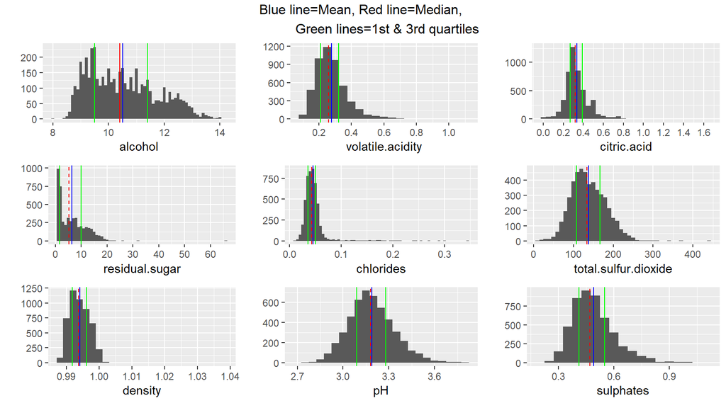

Many variables have fairly normal distributions but have long right tails. Some have outliers which will be shown more easily in the box plots in the next section.  
Alcohol content, Residual sugar and Density are right skewed with the median and mean pulled away from the mode and the mode close to the 1st quartile.  
Initial points of interest are:  
1. More wines fall at the dry end of the distribution.  
2. Most wines have a pH of around 3.1 to 3.3, which is as expected.  
3. Chlorides has a long right tail. These could be unpleasant salty wines.  
4. Volatile acidity has a right tail. These could be unpleasant tasting wines.  
I will now create boxplots to get a better idea of spread and outliers.

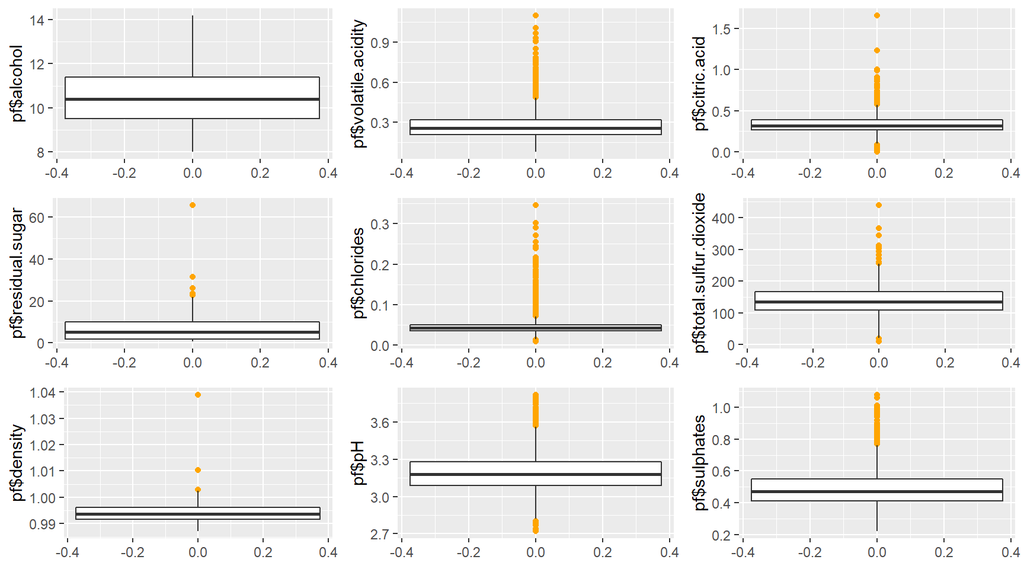

Alcohol does not have outliers.  
All other variables have outliers. Residual sugar and density have few but an extreme outlier. pH, total SO2, chlorides and citric acid have outliers on the left and right. Chlorides and volatile acidity have the most outliers.

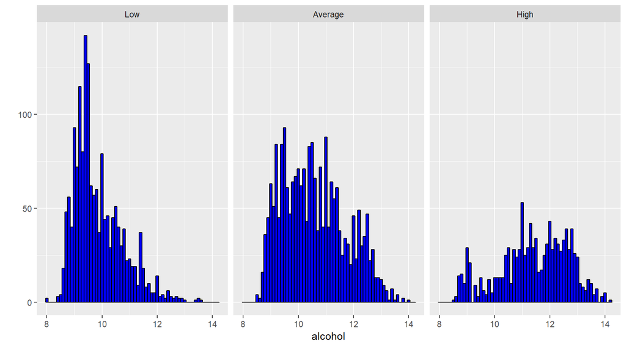

Splitting the analysis of alcohol content over quality, we can clearly see that there are few low quality wines with alcohol content over 12 (most are 9), and few high quality wines with acohol content under 9. High quality wines have a bimodal distribution peaking at around 9, and again at around 12.

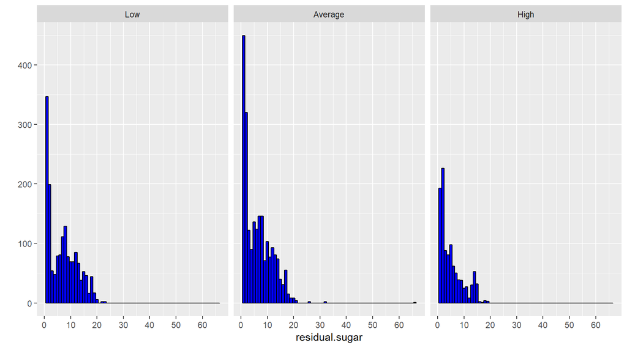

Splitting the analysis of residual sugar over quality, we can see that the outliers are found in average quality wine with a few sweeter average quality wines.

As the distribution is very right skewed I will transform it with log10 to get a better understanding of the distribution.

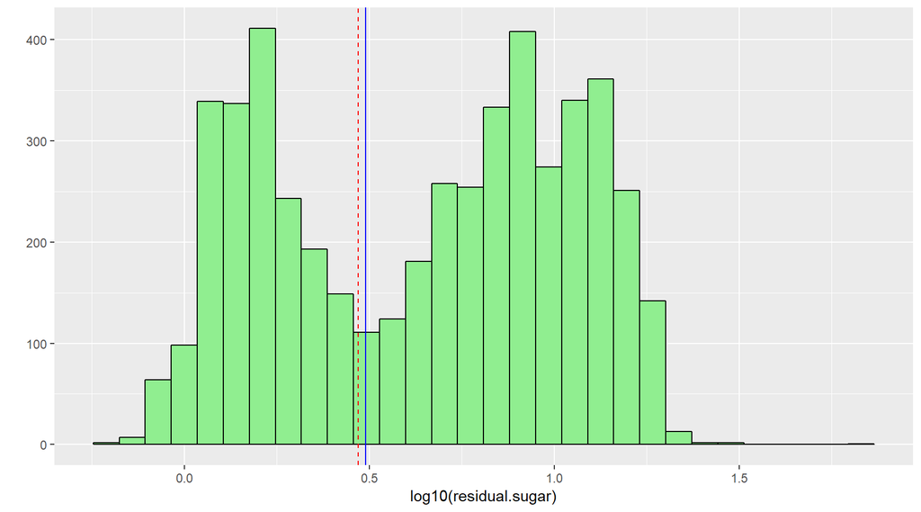

Residual sugar actually has a bimodal distribution with peaks at both dry and sweet distributions.

## Univariate Analysis

**Structure of the dataset**  
There are 4898 white wines in this dataset with 12 features:  
fixed.acidity, volatile.acidity, citric.acid, residual.sugar, chlorides, free.sulfur.dioxide, total.sulfur.dioxide, density, pH, sulphates, alcohol and quality.  
All of the input variables are are continuous data and numeric.  
Quality is the output (response) variable.It is a numeric categorical variable ranging from 0 - worst to 10 - best. However, these samples range from 3 to 9.  
**Main feature(s) of interest in the dataset**  
I would like to investigate which features are useful for determining the quality of white wine. I expect it will be a combination of a few variables.  
I am also interested in the features of high and low alcohol wines. The website https://winefolly.com/tutorial/the-lightest-to-the-strongest-wine suggests that:  
Low alcohol (<10%) wines will mostly be light and sweet.  
Medium low (10%-11.5%) will be less sweet as they are generally from cooler climates. Some are also more acidic as they are used for sparking wines.  
Medium (11%-13.5%) are usually drier.  
Medium high (13.5%-15%) are usually dry.

I would like see whether these statements can be proved in this data by investigating the alcohol and residual sugar variables. These have interesting distributions where the mode is furtheraway from the mean and median and closer to the 1st quartile.

**Other features to support the investigation**  
Density, volatile acidity, chlorides, SO2, pH  
winemakersacademy.com/importance-ph-wine-making/ discusses pH levels and states white wines should have a pH level lower than 3.3. However dessert wines can be up to 3.6 (less acidic) This fits in with my findings regarding IQR of the pH distribution.  
Also https://psuwineandgrapes.wordpress.com indicates that a low pH (high acidity) and “lower” sugar concentration is ideal for sparkling wine production.  
And a typical pH level for champagne could be 2.9. I would like to investigate if I can identify sparkling wines in the data.

**Did you create any new variables from existing variables in the dataset?**  
I created a new categorical variable quality.categs which divided the quality ratings into high, low and average. The plot of this showed that most wines were of average quality, and there were more low quality than high quality ones.

**Did you make any adjustments**  
I transformed the residual sugar distribution into a log10 scale and I adusted binwidths and the scale of x axes for most plots to get a better understanding of the distributions.

**Were there any unusual distributions.**  
Alcohol content, Residual sugar and density are right skewed with the median and mean pulled away from the mode and the mode close to the 1st quartile.  
From transforming the residual sugar distribuation using log10, I could see that the variable had a bimodal distribution.  
Residual sugar and density both had an extreme outlier on the right side of the distribution.

# Bivariate Plots Section

Firstly, correlation tables and pair plots will help identify relationships between the variables.

```
##                      fixed.acidity volatile.acidity  citric.acid
## fixed.acidity           1.00000000      -0.02269729  0.289180698
## volatile.acidity       -0.02269729       1.00000000 -0.149471811
## citric.acid             0.28918070      -0.14947181  1.000000000
## residual.sugar          0.08902070       0.06428606  0.094211624
## chlorides               0.02308564       0.07051157  0.114364448
## free.sulfur.dioxide    -0.04939586      -0.09701194  0.094077221
## total.sulfur.dioxide    0.09106976       0.08926050  0.121130798
## density                 0.26533101       0.02711385  0.149502571
## pH                     -0.42585829      -0.03191537 -0.163748211
## sulphates              -0.01714299      -0.03572815  0.062330940
## alcohol                -0.12088112       0.06771794 -0.075728730
## quality                -0.11366283      -0.19472297 -0.009209091
##                      residual.sugar   chlorides free.sulfur.dioxide
## fixed.acidity            0.08902070  0.02308564       -0.0493958591
## volatile.acidity         0.06428606  0.07051157       -0.0970119393
## citric.acid              0.09421162  0.11436445        0.0940772210
## residual.sugar           1.00000000  0.08868454        0.2990983537
## chlorides                0.08868454  1.00000000        0.1013923521
## free.sulfur.dioxide      0.29909835  0.10139235        1.0000000000
## total.sulfur.dioxide     0.40143931  0.19891030        0.6155009650
## density                  0.83896645  0.25721132        0.2942104109
## pH                      -0.19413345 -0.09043946       -0.0006177961
## sulphates               -0.02666437  0.01676288        0.0592172458
## alcohol                 -0.45063122 -0.36018871       -0.2501039415
## quality                 -0.09757683 -0.20993441        0.0081580671
##                      total.sulfur.dioxide     density            pH
## fixed.acidity                 0.091069756  0.26533101 -0.4258582910
## volatile.acidity              0.089260504  0.02711385 -0.0319153683
## citric.acid                   0.121130798  0.14950257 -0.1637482114
## residual.sugar                0.401439311  0.83896645 -0.1941334540
## chlorides                     0.198910300  0.25721132 -0.0904394560
## free.sulfur.dioxide           0.615500965  0.29421041 -0.0006177961
## total.sulfur.dioxide          1.000000000  0.52988132  0.0023209718
## density                       0.529881324  1.00000000 -0.0935914935
## pH                            0.002320972 -0.09359149  1.0000000000
## sulphates                     0.134562367  0.07449315  0.1559514973
## alcohol                      -0.448892102 -0.78013762  0.1214320987
## quality                      -0.174737218 -0.30712331  0.0994272457
##                        sulphates     alcohol      quality
## fixed.acidity        -0.01714299 -0.12088112 -0.113662831
## volatile.acidity     -0.03572815  0.06771794 -0.194722969
## citric.acid           0.06233094 -0.07572873 -0.009209091
## residual.sugar       -0.02666437 -0.45063122 -0.097576829
## chlorides             0.01676288 -0.36018871 -0.209934411
## free.sulfur.dioxide   0.05921725 -0.25010394  0.008158067
## total.sulfur.dioxide  0.13456237 -0.44889210 -0.174737218
## density               0.07449315 -0.78013762 -0.307123313
## pH                    0.15595150  0.12143210  0.099427246
## sulphates             1.00000000 -0.01743277  0.053677877
## alcohol              -0.01743277  1.00000000  0.435574715
## quality               0.05367788  0.43557472  1.000000000
```

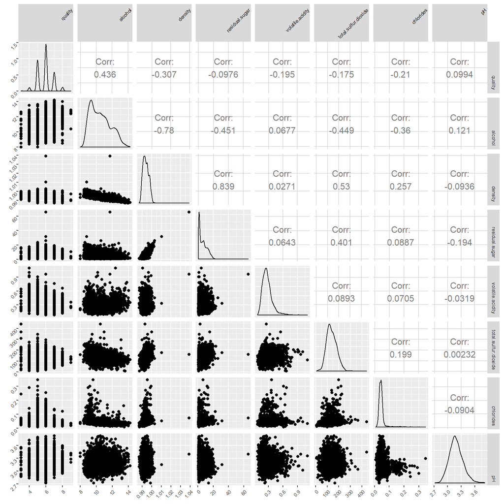

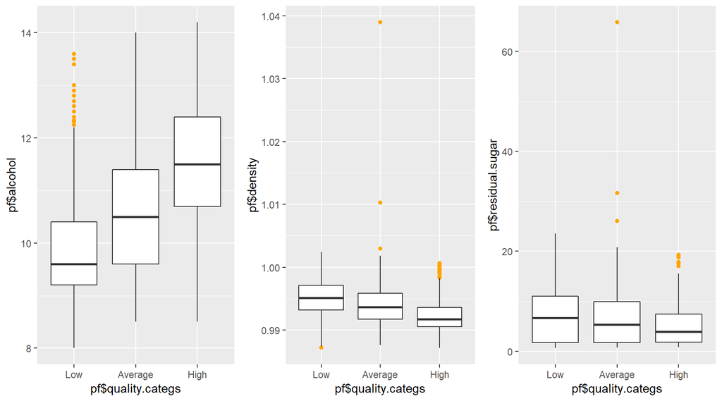

Using the quality.categs variable I created it is possible to see that higher quality wines tend to have a higher alcohol content.  
Higher quality wines tend to have lower density.  
It looks like there could be some relationship with residual sugar with higher quality wines having less sugar, even though there was no meaningful direct correlation.  
I will now investigate the relationships using scatter plots. Firstly, the relationships with quality.

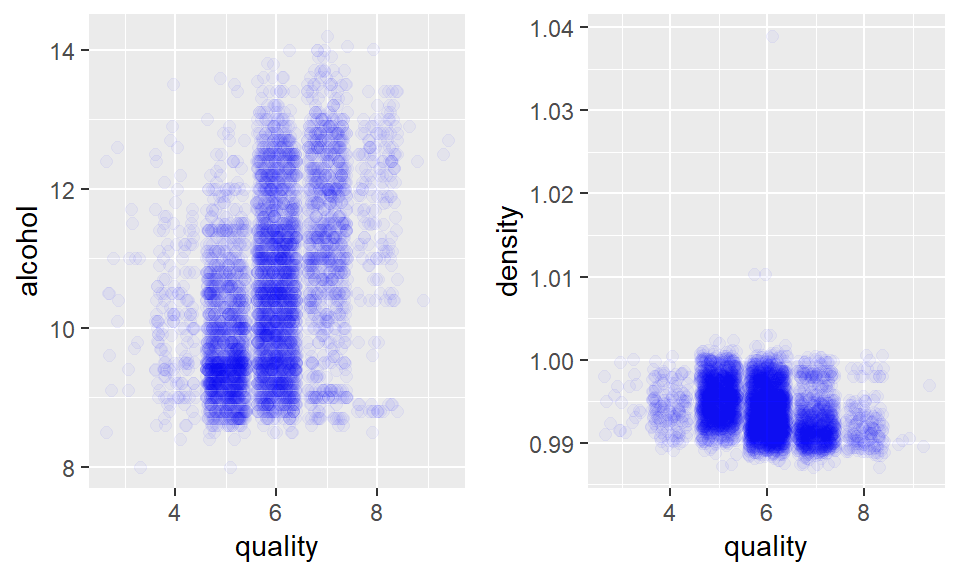

These scatterplots show small, linear associations between alcohol and quality, and density and quality. There is a positive association for alcohol and negative for density. There are outliers.  
A more significant relationship is between alcohol and density. As there were outliers in the density data I will remove the top 5%.

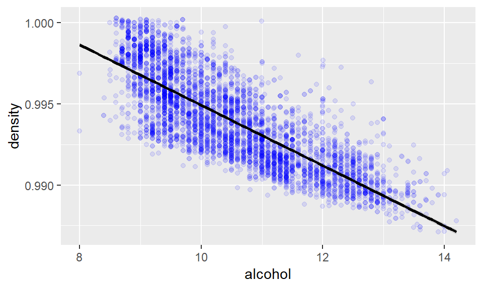

This scatterplot shows a stong, negative, linear association between alcohol and density. There are still a few outliers despite removing the top 5% of data values for density.

Next I will plot the most meaningful relationships with alcohol

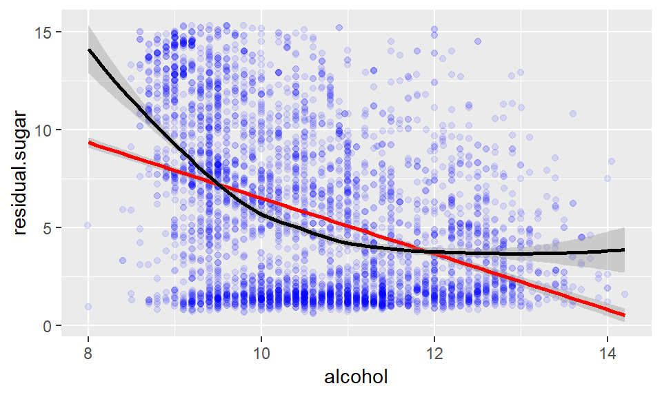

At first glance, this scatterplot shows very little association between alcohol and residual sugar. However, from the correlation coefficient, we know that there is a moderate, negative, linear association.

I remember that residual sugar has a bimodal distribution. I have used a linear and loess smoothing function in order to get a better idea of the trends. On closer inspection, it is possible to see 2 distinct areas of association.

Firstly, at the top left of the plot there is a concentration of low alcohol, sweeter wines and the trend is that wines become drier as alcohol content increases. The association then flattens showing that wines with average and higher alcoholic are more dry. There is also a concentration of dry wines across all levels of acohol content.

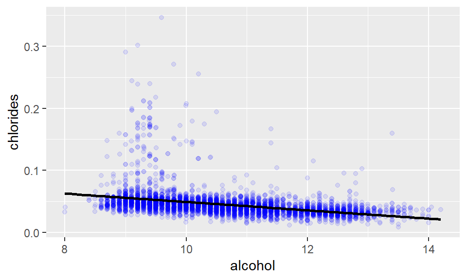

This scatterplot shows a moderate,linear association between alcohol and chlorides.  
It is interesting to see that at low alcohol levels there are quite a few points of high levels of chlorides. We already know that lower alcohol wines tend to be lower quality. I wonder if this could be due to a ‘salty’ taste.  
As I am looking at chlorides, which provide a salty taste, I would also like to plot this aginst volatile acidity, as high levels give an unpleasant taste. I was surprised that there was no meaningful correlation between these variables.

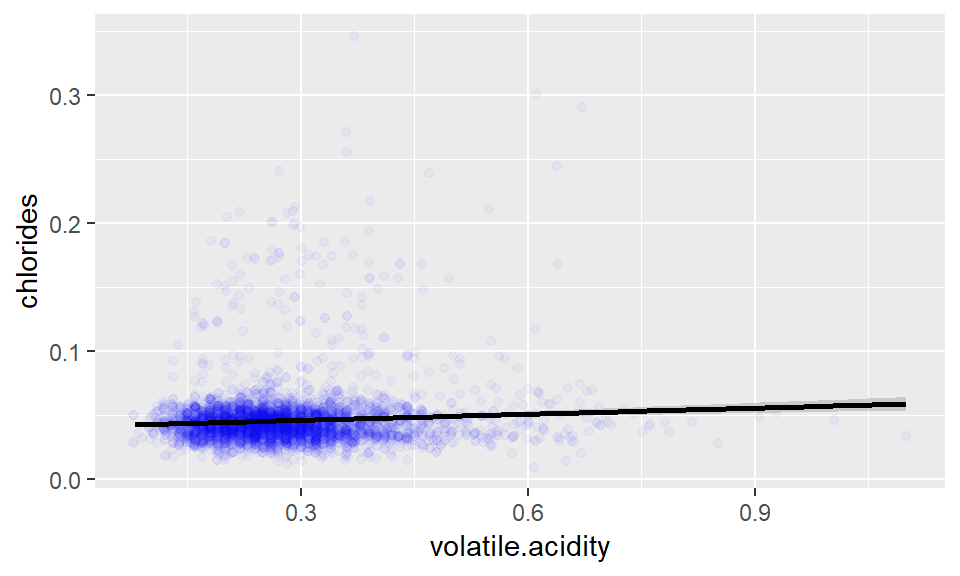

There is no clear relationship between these variables. The majority of values are low chlorides and low to moderate volatile acidity. But high levels of chorides are not associated with high levels of volatile acidity and vice versa.

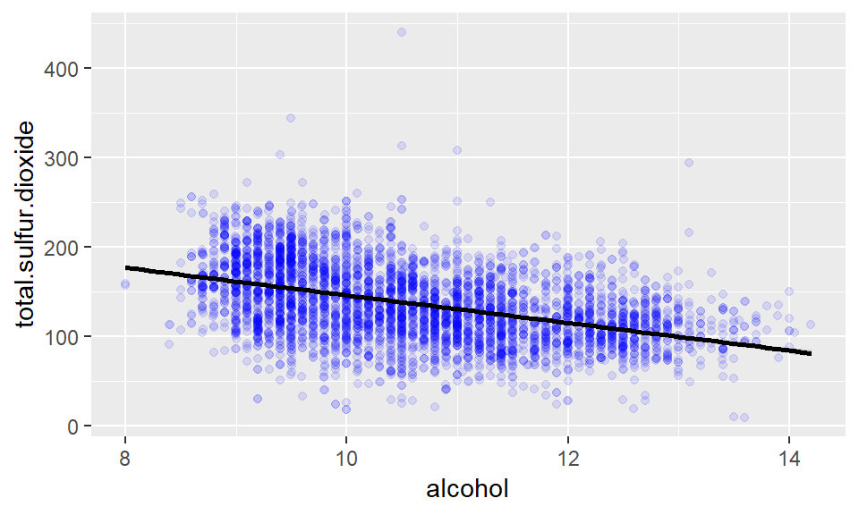

This scatterplot shows a moderat, linear association between alcohol and total SO2. On closer inspection I can see that at lower alcohol levels there is a concentration of higher total SO2, and this decreases as alcohol increases.  
Total SO2 is detectable at higher levels, so is this associated with high or low quality?  
Now to look at the associations with density.

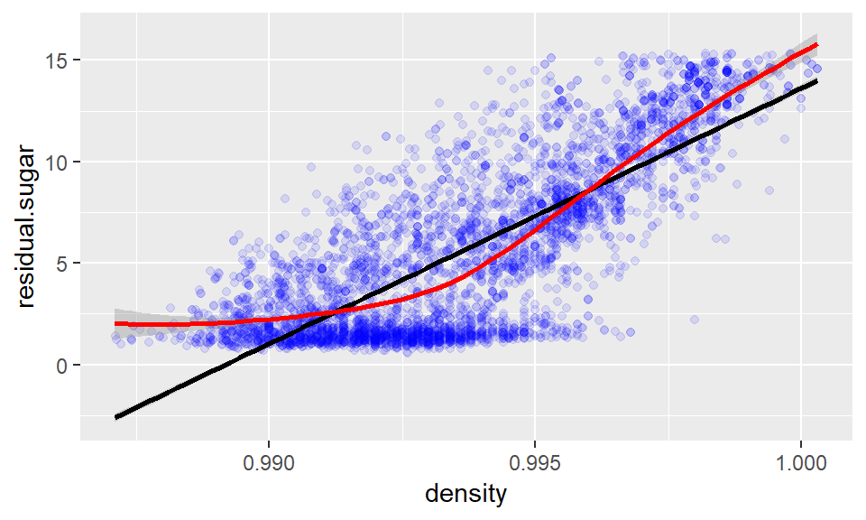

At first glance, it does not look like there is much of a relationship between density and residual sugar. But we know that they are highly correlated. We also know that residual sugar has a bimodal distribution. The loess line helps us to see the trends. At lower density levels residual sugar increases slightly as density increases. However for higher density levels residual sugar increases more sharply as density increases.  
There are 2 sections of concentration, low levels of residual sugar (dry wines) with low and moderately high density levels, and high sugar (sweet wines) associated with higher density levels.

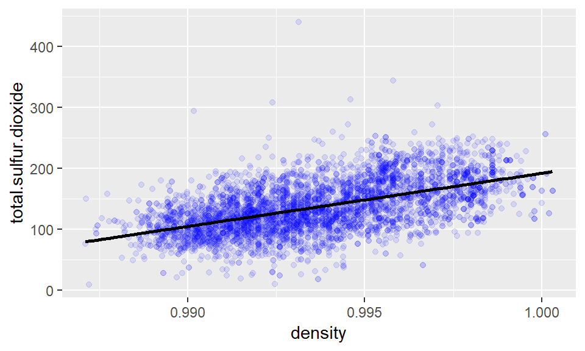

This scatterplot shows a moderate, positive, linear association between density and total SO2. As density increases there is an upward trend in total SO2. There are a few outliers.

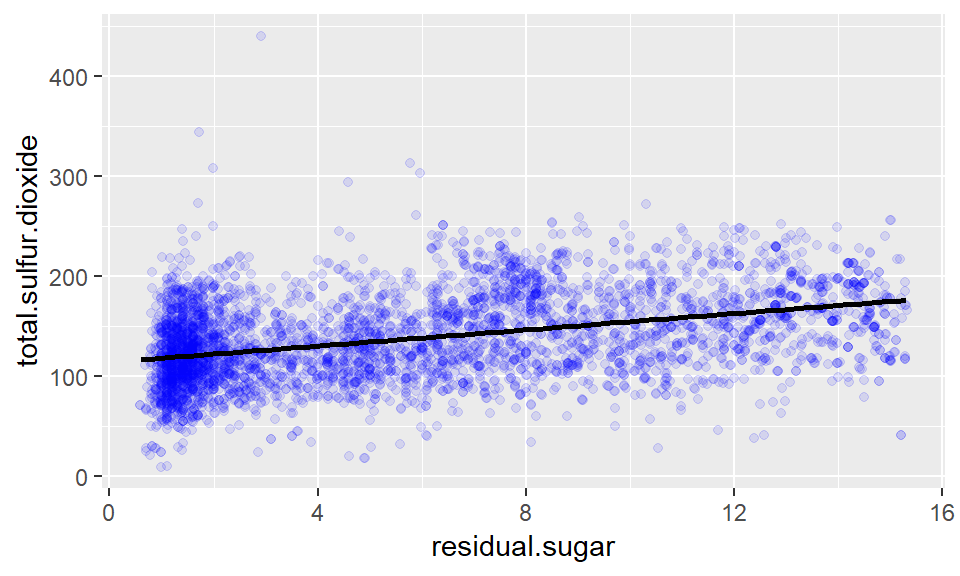

This scatterplot shows there is a moderate, positive, linear association between residual sugar and total SO2. The sweeter the wines the more SO2. There are outliers particuarly at lower sugar levels.

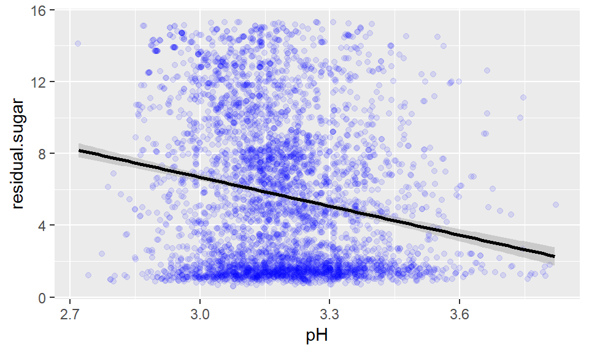

Finally, I was keen to investigate the relationship between pH and residual sugar due to my earlier research on some wines being dry and more acidic. The scatter plot does not show much association. However, there is a concentration of dry wines with with pH outside the IQR distribution so these lower pH points could be contenders for sparkling wines.

## Bivariate Analysis

** Rlationships observed in this part of the investigation **

I was interested to see that there was a negative association between alcohol and residual sugar. This supports my area of interest in investigating whether lower alcohol wines are sweeter and higher alcohol wines drier.  
As part of this I also wanted to explore the relationship between residual sugar and pH to see if the data supported the assertion that some medium low white wines would be more acidic as they are used for sparking wines.  
The plot did show that the highest pH values were for dry wines.  
I was also interested to see that chorides are negatively correlated with alcohol. So as alcohol levels increase, chorides decrease. As chlorides are salt, and I would assume that salty alcohol would not taste good, it would make sense that the higher quality wines have less chlorides.  
**What was the strongest relationship you found?**

The strongest relationship is between residual sugar and density. The correlation coefficient is 0.84 which shows that density increases as the level of sugar increases. This is not surprising as wines with more sugar would be more dense.  
# Multivariate Plots Section

Firstly, as the only meaningful correlations with quality are alcohol and density, I would like to look at both of these across quality to see where the highest quality wines are.

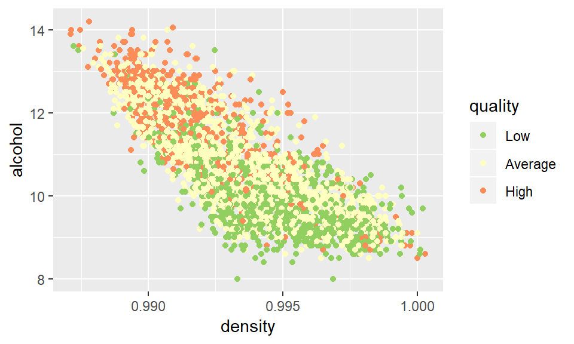

We can see that the higher quality wines are mostly associated with lower density (most likely dry) and higher alcohol content, while lower quality wines are mostly at the other end of the plot - higher density and lower alcohol.  
/ Now to address my question of whether chlorides give wine a more salty and unpleasant taste which would mean they are lower quality. And at this stage I would also like to return to looking at chlorides and volatile acidity to see if high levels of both of these are always low quality.

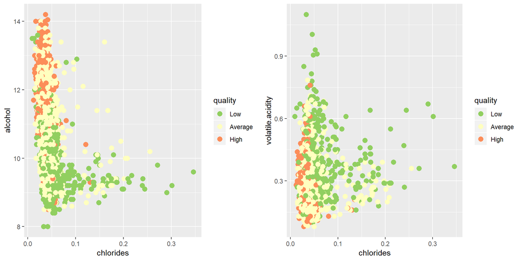

I can clearly see that there are no high quality wines with high levels of chlorides or high levels of volatile acidity. Furthermore, the highest levels of chorides and volatile acidity are low quality wines.  
Next to address the issues raised in my research that dry wines have higher alcohol content, and also that some dry wines are more acidic and some are used for sparkling wines. I wonder if it would be possible to identify which wines could be sparkling varieties by looking at these features?  
Firstly, I need to create a new categorical variable for alcohol. I will use the definitions from winefolly.com definitions (Low alcohol (<10%), Medium low (10%-11.5%), Medium (11%-13.5%), Medium high (13.5%-15%)

[output not shown]

```
##
##         Low  Medium Low      Medium Medium High
##        1822        1740        1001          29
```

Quick plot of the distribution to visualize it better.

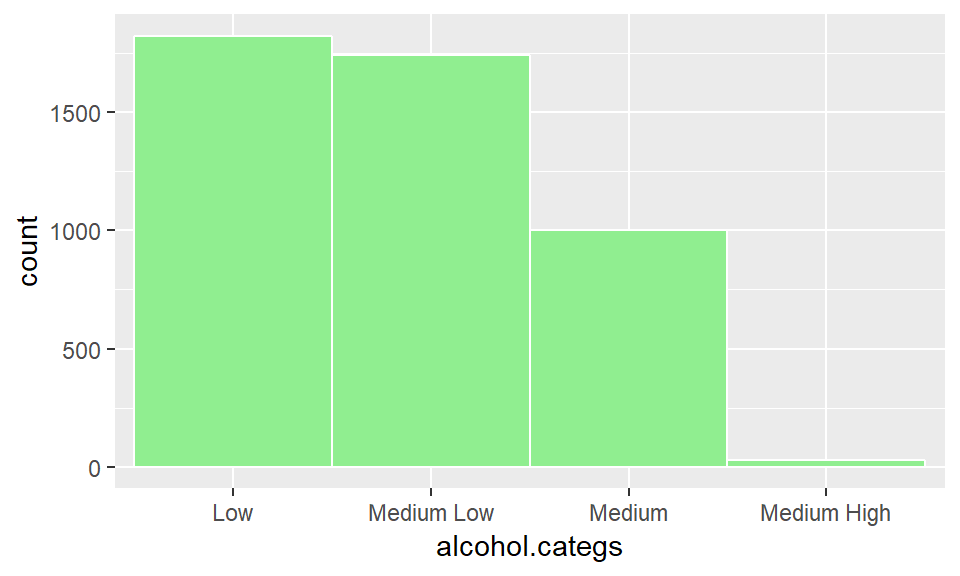

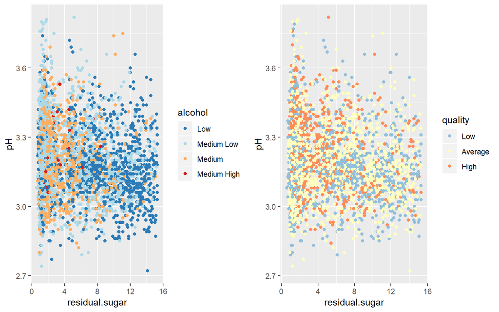

Looking at the bottom left of the plots, we can see dry and more acidic wines. These are contenders for sparkling varieties. The left graph shows that these related to mainly medium and medium dry varieties and also dry. The right graph indicates that these are mainly average and low quality wines.It would be nice to plot all of these features on the same graph.

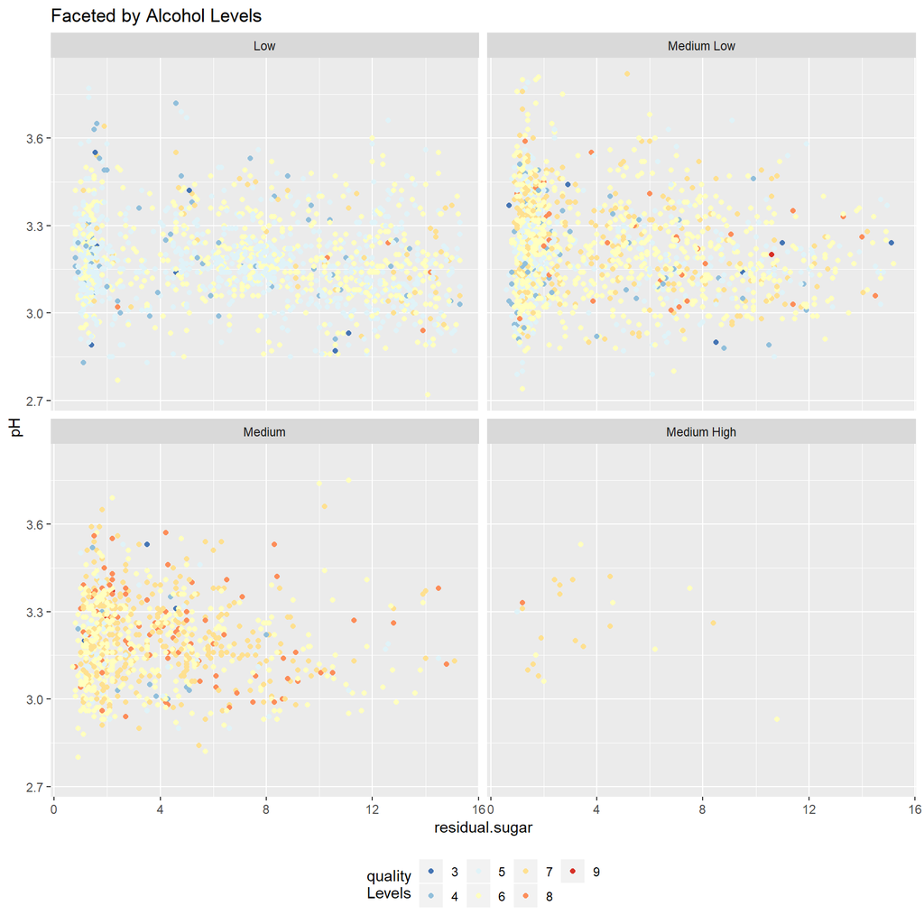

I am most interested in the bottom left part of the plots - the dry, more acidic wines which fit the profile for sparkling wines. There are mainly medium and medium dry and low wines here, but not many sweet wines at all. This fits in with the profile. Most of the points also fit into the average quality buckets.  
I will now focus in on this corner of the graph.

[figure not shown]

These are the drier more acidic wines, which could be contenders for sparkling wines.

# Multivariate Analysis

** The relationships I observed in this part of the investigation.**  
I looked at alcohol & density across the quality categorical variable as these variables had meaningful correlations with quality.I investigated whether there was a pattern for highest & lowest quality wines and found that higher quality wines were mostly associated with lower density and higher alcohol content, while lower quality wines were mostly higher density and lower alcohol.This was as I expected.  
Next I investigated whether higher levels of chlorides & volatile acidity were found in lower quality wines. I suspected they would be as they would have a more salty and unpleasant taste which would mean they are lower quality. The plots supported my assumption as there were no high quality wines with high levels of chlorides or volatile acidity. Furthermore, the highest levels of chlorides and volatile acidity were low quality wines.  
Next I looked at high alcohol, dry wines to see if they were more acidic in order to make some suggestions of which wines were more likely to be sparkling varieties. In order to do this I created a new categorical variable for alcohol content, I plotted the distribution then pH and residual sugar against alcohol and quality. I identified some samples which fitted the profile for sparkling wines.

# Final Plots and Summary

### Plot One

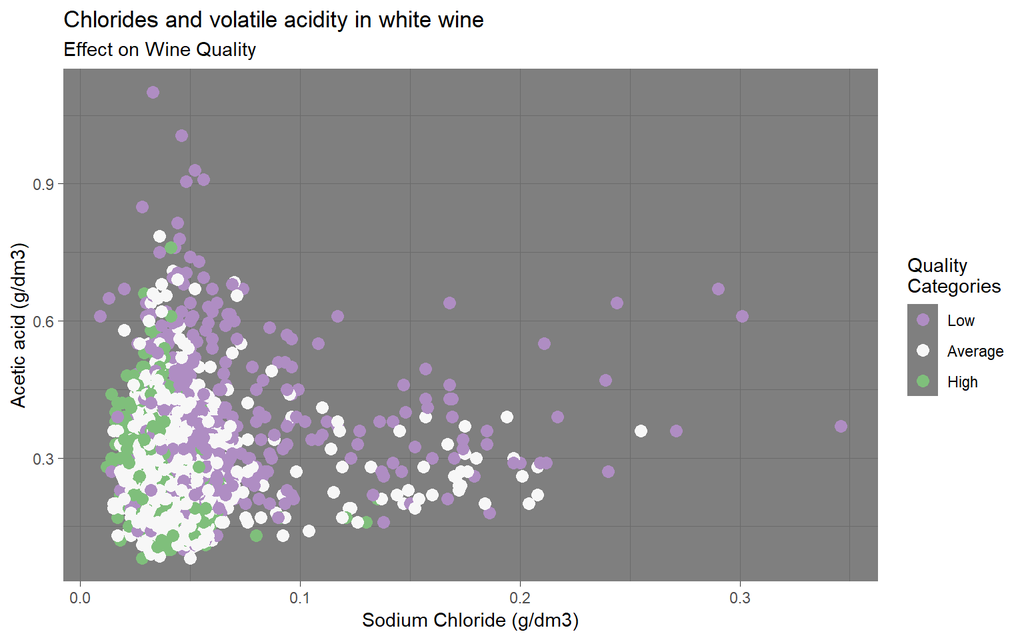

### Description One

This scatterplot shows quality evaluations of white wine associated with levels of chlorides (sodium chloride) and volatile acidity (acetic acid)  
High levels of chlorides in white wine are known to result in salty taste, and high levels of volatile acidity in wine are known to result in an unpleasant vinegary taste.  
Therefore I was interested in investigating whether these assumptions could be seen in this data by applying quality evaluations to the chlorides and volatile acidity attributes.  
The plot shows that these assumptions are refelected in the quality evaluations of the wine, as we can see that the low quality evaluations are mainly found in the extremities of the plot(high levels of chlorides or high levels of volatile acidity). Also, high quality wines are mainly associated with lower levels of these attributes.

### Plot Two

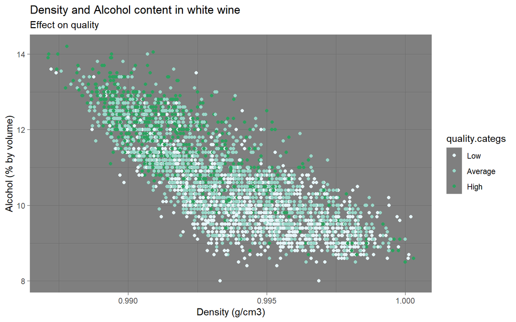

### Description Two

The scatterplot shows quality evaluations of white wine associated with alcohol content and density.  
The findings are that higher quality wines are mainly associated with high alcohol and low density levels, and conversely low quality wines are mainly associated with high density and low alcohol levels.  
I chose to present this plot because alcohol and density are the only features which have a direct meaningful correlation with white wine quality.

### Plot Three

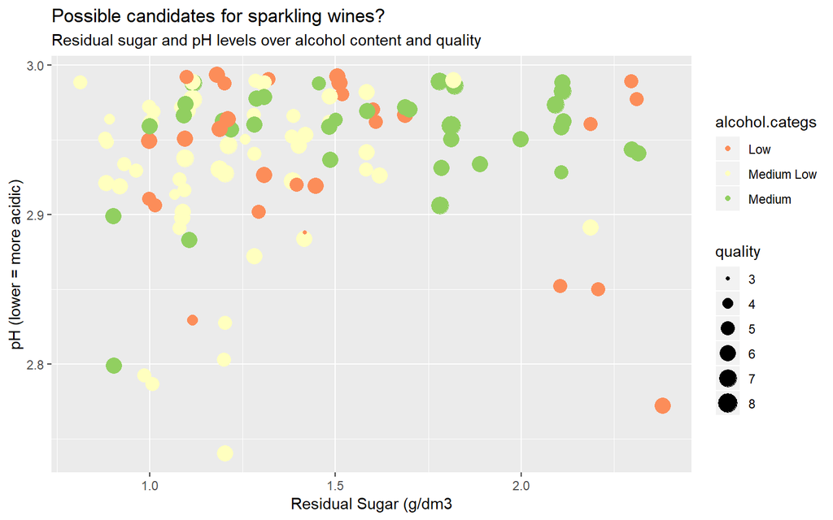

### Description Three

The scatterplot is a visualization of a subset of white wine data consistingof wine samples with low pH levels (more acidic) and low residual sugar levels - the driest wines in our sample. The plot also shows the alcohol content category of these samples.  
I chose to investigate this after discovering that sparkling wines tend to be drier and more acidic. Therefore, I wanted to present some samples which would be most likely to be sparkling wines if such wines existed in the dataset (a fact that is impossible to know from the features available in this dataset)  
It is interesting to note that no wines in this subset are in the high alcohol categories, they are also not the highest quality wines (which supports a statement made on vinepair.com that fizzy wines in this range are cheep and cheerful!).

# Reflection

Exploration of the white wine dataset turned out to be fairly complex as there were so many variables and combinations of those variables that could be analysed.  
However, it is worth noting that this dataset was clean so I did not need to perform any data wrangling / data cleansing tasks and there were no missing values to deal with.  
It was interesting to find out that very few features had meaningful correlations with quality at first glance. This was surprising to me because I expected residual sugar, chlorides and volatile acidity to be directly correlated as I thought they had big implications for taste. However, with more analysis, I found that I could draw out relationships and trends for quality associated with these features which supported my initial assumptions.  
My early research into white wine (see references to websites) piqued my interest as I discovered how dry wines tended to have higher alcohol content and also that sparkling wines tended to be more dry and acidic.  
I was interested in proving these statements by analysing the data, which I did in terms of residual sugarand alcohol content. However, a limitation of this dataset was that there was no feature to determine whether a wine was sparkling or not, therefore I couldn’t prove this statement, but nevertheless I was interested in presenting which ones might be candidates for sparkling wines if they did exist in the data.  
# References

1. https://winefolly.com/tutorial/the-lightest-to-the-strongest-wine
2. www.winemakersacademy.com/importance-ph-wine-making/
3. https://psuwineandgrapes.wordpress.com
4. https://vinepair.com/wine-blog/7-things-you-need-to-know-about-vinho-verde/